# Dynamic Plot Creation

Elizabeth King

Kevin Middleton

## What do we mean “dynamic”?

Use a template of code to do analysis and make a plot (and potentially other things)

- Reusable analysis
- Reusable plotting
- Edit once, use many times

## Mammals data

- Life history data for 5,400 species of mammals (PanTHERIA data)<sup>1</sup>
- Read data from tab-delimited file
- Replace -999 with NA
- Rename and select some traits to work with

```r
M <- read_delim("Data/mammals.txt", show_col_types = FALSE) |>
  mutate(across(.cols = where(is.double),
                .fns = ~ ifelse(.x == -999, NA, .x))) |>
  rename(Order = MSW05_Order,
         Species = MSW05_Binomial,
         Body_mass = `5-1_AdultBodyMass_g`,
         Forearm = `8-1_AdultForearmLen_mm`,
         Body_length = `13-1_AdultHeadBodyLen_mm`,
         Eye_opening = `2-1_AgeatEyeOpening_d`,
         Repro_age = `3-1_AgeatFirstBirth_d`,
         BMR_1 = `18-1_BasalMetRate_mLO2hr`,
         BMR_2 = `5-2_BasalMetRateMass_g`,
         Neonate_mass = `5-3_NeonateBodyMass_g`) |>
  select(Order, Species, Body_mass, Forearm, Body_length, Eye_opening,
         Repro_age, BMR_1, BMR_2, Neonate_mass)
M
```

[^1]: Kate E. Jones, et al.. 2009. PanTHERIA: a species-level database of life history, ecology, and geography of extant and recently extinct mammals. Ecology 90:2648.

## Mammals data

```
# A tibble: 5,416 × 10
   Order   Species Body_…¹ Forearm Body_…² Eye_o…³ Repro…⁴  BMR_1  BMR_2 Neona…⁵
   <chr>   <chr>     <dbl>   <dbl>   <dbl>   <dbl>   <dbl>  <dbl>  <dbl>   <dbl>
 1 Artiod… Camelu… 492714.      NA     NA     NA     1652. 40293  407000 36751.
 2 Carniv… Canis …  10392.      NA    745.    NA       NA     NA      NA    NA
 3 Carniv… Canis …   9659.      NA    828.     7.5     NA     NA      NA   212.
 4 Carniv… Canis …  11989.      NA    872.    11.9    365   3699   10450   200.
 5 Carniv… Canis …  31757.      NA   1055     14.0    548. 11254.  33100   412.
 6 Artiod… Bos fr… 800143.      NA   2700     NA       NA     NA      NA 22977.
 7 Artiod… Bos gr… 500000       NA     NA     NA       NA     NA      NA    NA
 8 Artiod… Bos ja… 635974.      NA   2075     NA      912.    NA      NA    NA
 9 Primat… Callic…   1117.      NA    355.    NA       NA     NA      NA    73.6
10 Primat… Callic…     NA       NA     NA     NA       NA     NA      NA    NA
# … with 5,406 more rows, and abbreviated variable names ¹Body_mass,
#   ²Body_length, ³Eye_opening, ⁴Repro_age, ⁵Neonate_mass
```

## Working with lists

- Lists can hold any kind of R object
- Easy to create empty lists and fill

```r
ll <- list()

ll[[1]] <- 1
ll[[2]] <- 3
ll
```

```
[[1]]
[1] 1

[[2]]
[1] 3
```

Create a counter and iterate through the traits.

## Functions that generate plots

```r
trait_plot <- function(trait) {
  D <- tibble(trait) |> drop_na()
  p <- ggplot(D, aes(trait)) +
    geom_histogram(bins = 30)
  return(p)
}
```

## Testing the function

```r
trait_plot(M$Forearm)
```

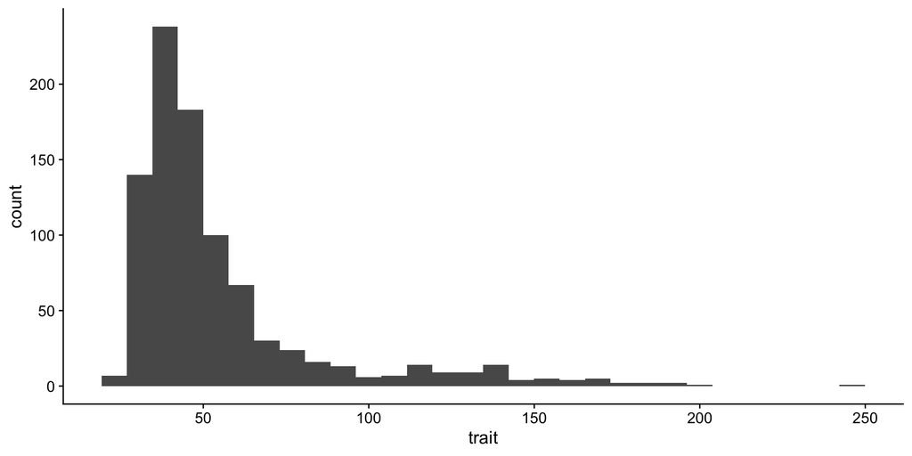

## Collecting plots in lists 1

- Setup the vectors of traits

```r
traits <- names(M)[3:10]
traits
```

```
[1] "Body_mass"    "Forearm"      "Body_length"  "Eye_opening"  "Repro_age"
[6] "BMR_1"        "BMR_2"        "Neonate_mass"
```

## Collecting plots in lists 2

- Make an empty list of plots
- `select()` the *ii*th trait by string (`all_of()`)
- Convert to vector (`pull()`)

```r
plots <- list()
for (ii in 1:length(traits)) {
  trait <- M |>
    select(all_of(traits[ii])) |>
    pull(1)
  plots[[ii]] <- trait_plot(trait)
}
```

## Checking plots

```r
plots[[1]]
```

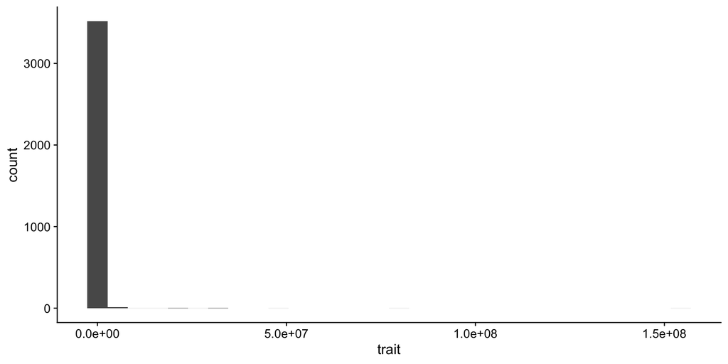

## View all plots

```r
wrap_plots(plots)
```

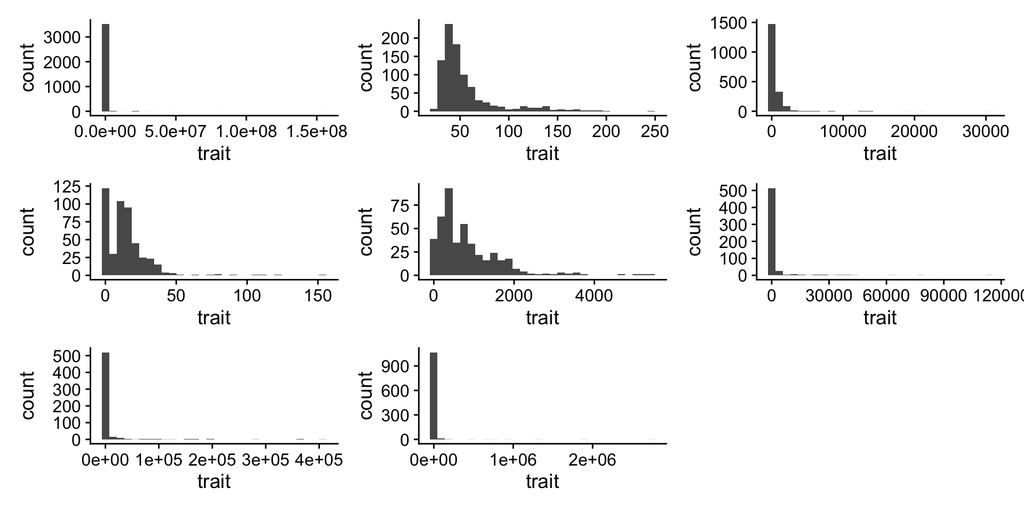

## Rewriting `trait_plot`

- `trait` is a string
- Drop rows with `NA` using `drop_na(all_of(trait))`
- Set `aes()` to `trait` with `.data[[trait]]`

```r
trait_plot_map <- function(trait, M) {
  M_no_NA <- M |>
    drop_na(all_of(trait))
  p <- ggplot(M_no_NA, aes(.data[[trait]])) +
    geom_histogram(bins = 30) +
    labs(x = str_replace(trait, "_", " "))
  return(p)
}
```

## `purrr::map_` functions

- Efficiently pass a set of values to a function and collect results
- Functions can return:
  - `numeric`, `data.frame`/`tibble`, etc.
- `map()` collects returns to a list

## Using `purrr::map()`

- `.x` is the iterable vector to pass to the function `.f` (note no `()`)
- `M` is passed as an additional parameter

```r
plots_map <- map(.x = names(M)[3:10],
                 .f = trait_plot_map,
                 M = M)
```

## Checking plots

```r
wrap_plots(plots_map)
```

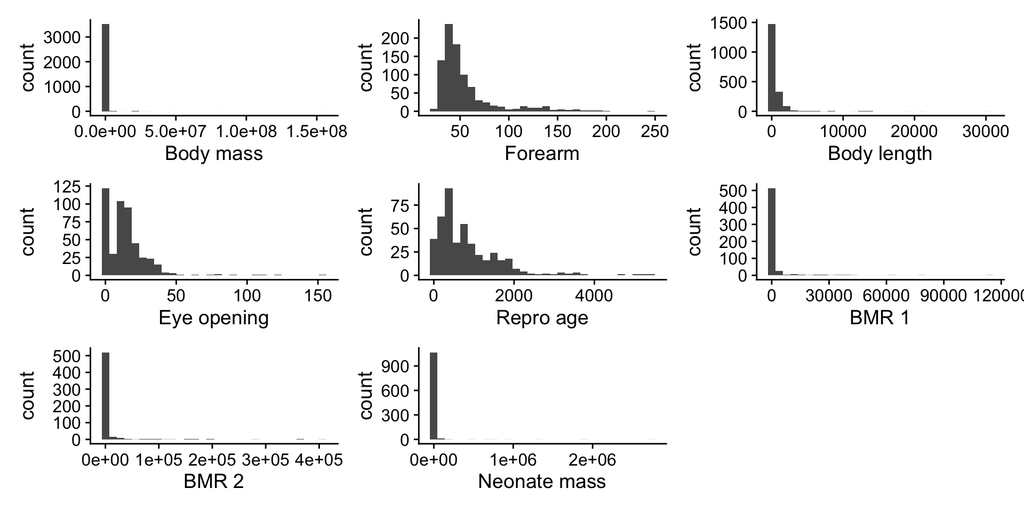

## I could have just used `pivot_longer()` and `facet_wrap()`

Yes. But…

[figure not shown]